# **Analisis Clustering K-Means Pada Data Sakila**

Angwin Meilisa Aulia - M0723012

# Pendahuluan

Dalam penelitian kali ini dilakukan analisis Clustering K-Means untuk mengelompokkan kategori film berdasarkan **Total Rental & Total Revenue**

# Install Package yang Dibutuhkan

Hal pertama yang harus dilakukan adalah menginstall package yang akan dibutuhkan nantinya untuk melakukan analisis data.

```r
library(DBI)
library(RMySQL)
library(tidyverse)
library(ggplot2)
library(cluster)
library(factoextra)
library(scales)
```

# Connect ke Database Sakila

Dilanjutkan dengan menghubungkan *software* RStudio dengan databse MySQL Sakila. Koneksi tersebut diperlukan agar data pada database dapat diakses, diambil, dan dianalisis menggunakan bahawa pemrograman R.

```r
con <- dbConnect(
  RMySQL::MySQL(),
  dbname = "sakila",
  host = "localhost",
  port = 3306,
  user = "root",
  password = "deksol1234"
)
```

# Pengambilan Data

Tahapan pengambilan data dilakukan dengan menggunakan query SQL untuk meperoleh data yang relevan dengan tujuan analisis. Data yang diambil meliputi informasi Total Rental dan Total Revenue pada masing-masing kategori film. Hasil query kemudian disimpan kedalam dataframe di R untuk dilakukan preprocessing, visualisasi, dan analisis clustering.

```r
query <- "
SELECT
    c.name AS category,
    COUNT(r.rental_id) AS total_rental,
    SUM(p.amount) AS total_revenue
FROM category c
JOIN film_category fc
    ON c.category_id = fc.category_id
JOIN film f
    ON fc.film_id = f.film_id
JOIN inventory i
    ON f.film_id = i.film_id
JOIN rental r
    ON i.inventory_id = r.inventory_id
JOIN payment p
    ON r.rental_id = p.rental_id
GROUP BY c.name
"

sakila_data <- dbGetQuery(con, query)

sakila_data
```

```
##       category total_rental total_revenue
## 1       Action         1112       4375.85
## 2    Animation         1166       4656.30
## 3     Children          945       3655.55
## 4     Classics          939       3639.59
## 5       Comedy          941       4383.58
## 6  Documentary         1050       4217.52
## 7        Drama         1060       4587.39
## 8       Family         1096       4226.07
## 9      Foreign         1033       4270.67
## 10       Games          969       4281.33
## 11      Horror          846       3722.54
## 12       Music          830       3417.72
## 13         New          940       4351.62
## 14      Sci-Fi         1101       4756.98
## 15      Sports         1179       5314.21
## 16      Travel          837       3549.64
```

# Preprocessing Data

Sebelum dilakukan clustering, variabel numerik di normalisasi menggunakan fungsi **scale()**. Langkah tersebut merupakan langkah penting dalam algoritma berbasis jarak seperti K-Means agar skala data seimbang. Tanpa normalisasi, variabel Total Revenu yang memiliki rentang ribuang akan mendominasi perhitungan jarak dibandingkan dengan Total Rental yang rentangnya lebih kecil.

```r
cluster_data <- sakila_data %>%
  select(total_rental, total_revenue)

cluster_scaled <- scale(cluster_data)

head(cluster_scaled)
```

```
##      total_rental total_revenue
## [1,]    0.9641399   0.320337137
## [2,]    1.4406942   0.871696840
## [3,]   -0.5096483  -1.095759830
## [4,]   -0.5625988  -1.127136905
## [5,]   -0.5449486   0.335534179
## [6,]    0.4169850   0.009063178
```

# Menentukan Jumlah Cluster

Penentuan jumlah clister merupakan tahapan penting dalam metode K-Means Clustering. Jumlah cluster yang terlalu sedikit dapat menyebabkan informasi penting hilang. Sedangkan jumlah cluster yang terlalu banyak dapat menyebabkan hasil clustering menjadi kurang efektif.

Pada penelitian ini digunakan metode *Elbow Method* untuk menentukan jumlah cluster optimal. Metode ini dilakukan dengan melihat penurunan nilai *Within Cluster Sum of Squares (WSS)* pada setiap jumlah cluster.

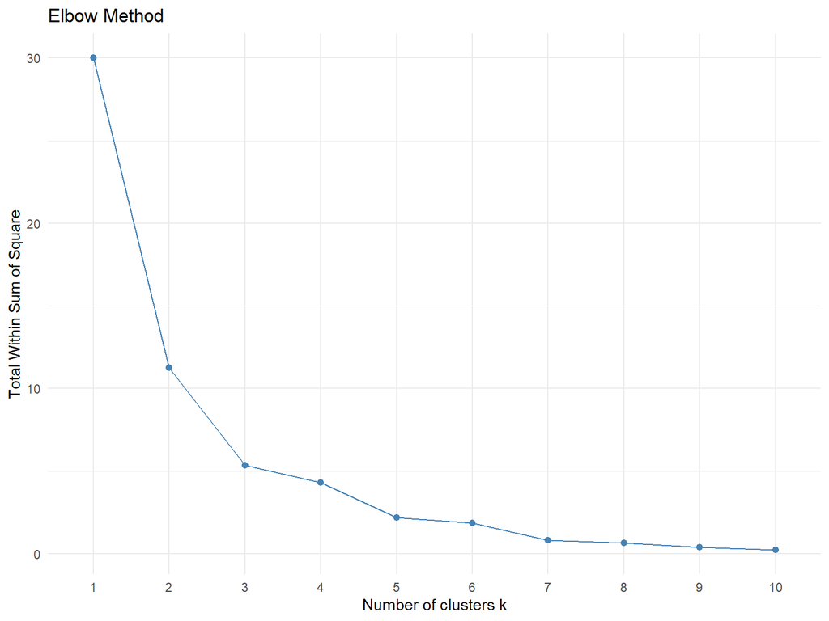

```r
library(ggpubr)
fviz_nbclust(
  cluster_scaled,
  kmeans,
  method = "wss"
) +
  labs(
    title = "Elbow Method"
  ) +
  theme_minimal()
```

Dari visualisasi *Elbow Method* tersebut menunjukkan grafik penurunan nilai *Within Sum of Squares (WSS)* seiring bertambahnya jumlah cluster. Penurunan paling curam dan mulai melandai (membentuk siku) terjadi pada angka 3. Oleh karena itu ditetapkan nilai k = 3.

# K-Means Clustering

K-Means clustering merupakan metode *unsupervised learning* yang digunakan untuk mengelompokkan data berdasarkan kemiripan karakteristik. K-Means Clustering bekerja dengan membagi data ke dalam beberapa cluster berdasarkan jarak terhadap centroid cluster. Pada analisis ini menggunakan :
$$k = 3$$

```r
set.seed(123)

kmeans_result <- kmeans(
  cluster_scaled,
  centers = 3,
  nstart = 25
)

kmeans_result
```

```
## K-means clustering with 3 clusters of sizes 3, 5, 8
##
## Cluster means:
##   total_rental total_revenue
## 1    1.2877262     1.3688216
## 2   -1.0885735    -1.2108524
## 3    0.1974611     0.2434746
##
## Clustering vector:
##  [1] 3 1 2 2 3 3 3 3 3 3 2 2 3 1 1 2
##
## Within cluster sum of squares by cluster:
## [1] 1.242780 1.242833 2.876707
##  (between_SS / total_SS =  82.1 %)
##
## Available components:
##
## [1] "cluster"      "centers"      "totss"        "withinss"     "tot.withinss"
## [6] "betweenss"    "size"         "iter"         "ifault"
```

Dari output algoritma tersebut menunjukkan metrik between_SS / total_SS = 82.1%. Angka tersebut merupakan indikator performa yang sangat baik. Hal tersebut mengartikan bahwa model dengan 3 cluster ini mampu menjelaskan 82.1% keragaman datara antar kategori film.

# Menambahkan Label Cluster

Setelah melakukan Cluster K-Means, setiap data kategori film akan memperoleh label cluster sesuai dengan hasil pengelompokan yang terbentuk. Label cluster digunakan untuk menunjukkan kelompok kategori film berdasarkan kemiripan karakteristik data.

```r
sakila_data$cluster <- as.factor(kmeans_result$cluster)

sakila_data
```

```
##       category total_rental total_revenue cluster
## 1       Action         1112       4375.85       3
## 2    Animation         1166       4656.30       1
## 3     Children          945       3655.55       2
## 4     Classics          939       3639.59       2
## 5       Comedy          941       4383.58       3
## 6  Documentary         1050       4217.52       3
## 7        Drama         1060       4587.39       3
## 8       Family         1096       4226.07       3
## 9      Foreign         1033       4270.67       3
## 10       Games          969       4281.33       3
## 11      Horror          846       3722.54       2
## 12       Music          830       3417.72       2
## 13         New          940       4351.62       3
## 14      Sci-Fi         1101       4756.98       1
## 15      Sports         1179       5314.21       1
## 16      Travel          837       3549.64       2
```

# Visualisasi Cluster

Visualisasi berikut menunjukkan hasil pengelompokan kategori film berdasarkan total rental dan total revenue.

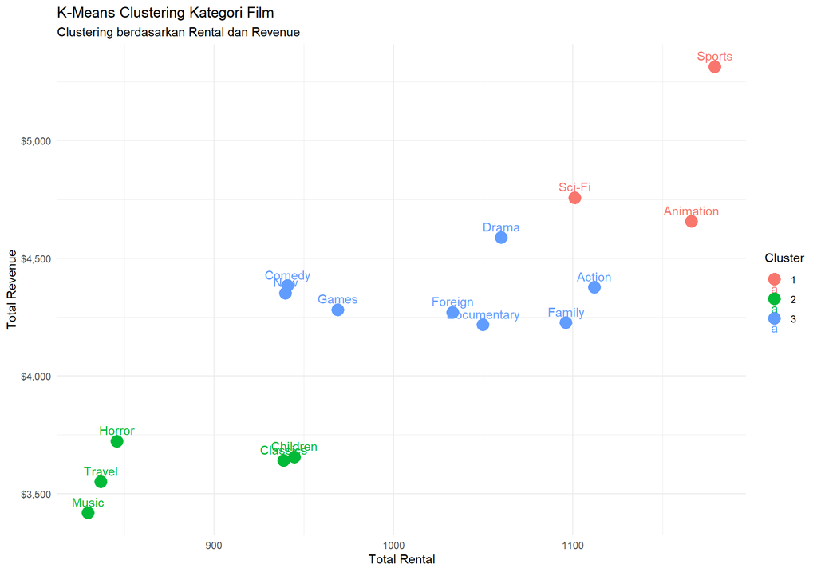

```r
ggplot(
  sakila_data,
  aes(
    x = total_rental,
    y = total_revenue,
    color = cluster,
    label = category
  )
) +
  geom_point(size = 5) +
  geom_text(vjust = -0.7) +
  labs(
    title = "K-Means Clustering Kategori Film",
    subtitle = "Clustering berdasarkan Rental dan Revenue",
    x = "Total Rental",
    y = "Total Revenue",
    color = "Cluster"
  ) +
  scale_y_continuous(
    labels = dollar_format()
  ) +
  theme_minimal()
```

## Cluster 1 (Warna Merah)

Kelompok tersebut menempati posisi di kanan atas grafik yang artinya memiliki angka **Total Rental tertinggi** (lebih dari 1.100 kali) dan **Total Revenue terbesar** ($4.500 hingga >$5.000). Kategori film yang berada di Cluster 1 adalah Sports, Sci-Fi, dan Animation.

## Cluster 2 (Warna Hijau)

Kelompok tersebut menempati posisi di area kiri bawah grafik yang mengindikasikan angka **Total Rental terendah** (<950 kali) dan **Total Revenue paling rendah** (<$4.000). Kategori film yang berada di cluster 2 adalah Music, Travel, Horror, classicsm dan Children.

## Cluter 3 (Warna Biru)

Kelompok tersebut berada di tengah-tengah grafik dengan angka **Total Rental dan Total Revenue** berada di tengah-tengah grafik. Angka *Total Rental & Total Revenue* betada di tingkatan sedang atau rata-rata. Kategori film yang ada pada kategori sedang ini adalah Drama, Action, Comedy, New, Games, Foreign, Documentary, dan Family

Dari visualisasi tersebut terlihat bahwa semakin tinggi total rental maka semakin besar total revenuenya. Pemisahan warna cluster juga mempertegas bahwa tidak ada tumpang tindih yang parah dalam pembagian clustering.

# Visualisasi Centroid Cluster

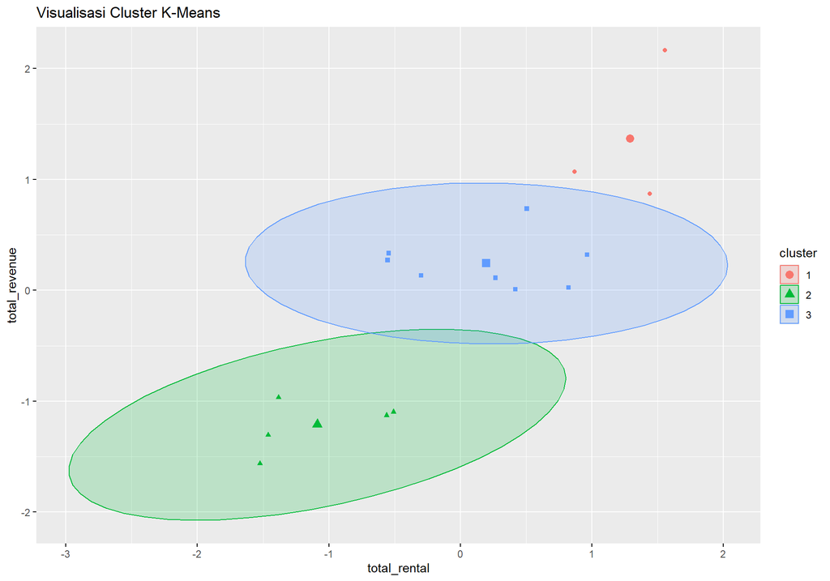

```r
fviz_cluster(
  kmeans_result,
  data = cluster_scaled,
  geom = "point",
  ellipse.type = "norm",
  main = "Visualisasi Cluster K-Means"
)
```

# Ringkasan Cluster

```r
sakila_data %>%
  group_by(cluster) %>%
  summarise(
    avg_rental = mean(total_rental),
    avg_revenue = mean(total_revenue),
    jumlah_kategori = n()
  )
```

```
## # A tibble: 3 × 4
##   cluster avg_rental avg_revenue jumlah_kategori
##   <fct>        <dbl>       <dbl>           <int>
## 1 1            1149.       4909.               3
## 2 2             879.       3597.               5
## 3 3            1025.       4337.               8
```